# TP2_7.2

Emily Schmidt

2022-11-06

```r
library(data.table) # Fast aggregation of large data sets and a fast file reader
library(lubridate) # Commute date-times
library(cowplot) # A simple add-on to ggplot
library(caret) # Functions that attempt to streamline the process for creating predictive models
library(kableExtra) # Add elements to a a pivot table
library(reshape2) # Easily transform our data into whatever structure we may need
library(fastDummies) # Provides a significant speed increase from creating dummy variables
library(randomizr) # Generates random assignments for common experimental designs and random samples for common sampling designs
library(FNN) # Used for KNN estimation
library(tidyr) # Contains tools for changing the shape and hierarchy of a data set
library(DataExplorer) # Used to graph missing value percentages
```

```r
setwd("C:\\Users\\emann\\GSEM Master\\Data Mining\\Homework 2") # Set directory
getwd() # Check the working directory
```

```
## [1] "C:/Users/emann/GSEM Master/Data Mining/Homework 2"
```

```r
UniBank <- read.csv("UniversalBank.csv", sep = ",", header = T) # Load your data, UniversalBank
```

```r
dim(UniBank) # Get or set the dimension of the specified matrix, array or data frame
```

```
## [1] 5000   14
```

```r
head(UniBank) # Display the first n rows present in the input data frame
```

```
##   ID Age Experience Income ZIP.Code Family CCAvg Education Mortgage
## 1  1  25          1     49    91107      4   1.6         1        0
## 2  2  45         19     34    90089      3   1.5         1        0
## 3  3  39         15     11    94720      1   1.0         1        0
## 4  4  35          9    100    94112      1   2.7         2        0
## 5  5  35          8     45    91330      4   1.0         2        0
## 6  6  37         13     29    92121      4   0.4         2      155
##   Personal.Loan Securities.Account CD.Account Online CreditCard
## 1             0                  1          0      0          0
## 2             0                  1          0      0          0
## 3             0                  0          0      0          0
## 4             0                  0          0      0          0
## 5             0                  0          0      0          1
## 6             0                  0          0      1          0
```

```r
View(UniBank) # Invoke a spreadsheet-style data viewer within RStudio
summary(UniBank) # Produce result summaries of the results of various model fitting functions
```

```
##        ID            Age          Experience       Income          ZIP.Code
##  Min.   :   1   Min.   :23.00   Min.   :-3.0   Min.   :  8.00   Min.   : 9307
##  1st Qu.:1251   1st Qu.:35.00   1st Qu.:10.0   1st Qu.: 39.00   1st Qu.:91911
##  Median :2500   Median :45.00   Median :20.0   Median : 64.00   Median :93437
##  Mean   :2500   Mean   :45.34   Mean   :20.1   Mean   : 73.77   Mean   :93153
##  3rd Qu.:3750   3rd Qu.:55.00   3rd Qu.:30.0   3rd Qu.: 98.00   3rd Qu.:94608
##  Max.   :5000   Max.   :67.00   Max.   :43.0   Max.   :224.00   Max.   :96651
##      Family          CCAvg          Education        Mortgage
##  Min.   :1.000   Min.   : 0.000   Min.   :1.000   Min.   :  0.0
##  1st Qu.:1.000   1st Qu.: 0.700   1st Qu.:1.000   1st Qu.:  0.0
##  Median :2.000   Median : 1.500   Median :2.000   Median :  0.0
##  Mean   :2.396   Mean   : 1.938   Mean   :1.881   Mean   : 56.5
##  3rd Qu.:3.000   3rd Qu.: 2.500   3rd Qu.:3.000   3rd Qu.:101.0
##  Max.   :4.000   Max.   :10.000   Max.   :3.000   Max.   :635.0
##  Personal.Loan   Securities.Account   CD.Account         Online
##  Min.   :0.000   Min.   :0.0000     Min.   :0.0000   Min.   :0.0000
##  1st Qu.:0.000   1st Qu.:0.0000     1st Qu.:0.0000   1st Qu.:0.0000
##  Median :0.000   Median :0.0000     Median :0.0000   Median :1.0000
##  Mean   :0.096   Mean   :0.1044     Mean   :0.0604   Mean   :0.5968
##  3rd Qu.:0.000   3rd Qu.:0.0000     3rd Qu.:0.0000   3rd Qu.:1.0000
##  Max.   :1.000   Max.   :1.0000     Max.   :1.0000   Max.   :1.0000
##    CreditCard
##  Min.   :0.000
##  1st Qu.:0.000
##  Median :0.000
##  Mean   :0.294
##  3rd Qu.:1.000
##  Max.   :1.000
```

```r
str(UniBank) # Compactly displaying the internal structure of a R object
```

```
## 'data.frame':    5000 obs. of  14 variables:
##  $ ID                : int  1 2 3 4 5 6 7 8 9 10 ...
##  $ Age               : int  25 45 39 35 35 37 53 50 35 34 ...
##  $ Experience        : int  1 19 15 9 8 13 27 24 10 9 ...
##  $ Income            : int  49 34 11 100 45 29 72 22 81 180 ...
##  $ ZIP.Code          : int  91107 90089 94720 94112 91330 92121 91711 93943 90089 93023 ...
##  $ Family            : int  4 3 1 1 4 4 2 1 3 1 ...
##  $ CCAvg             : num  1.6 1.5 1 2.7 1 0.4 1.5 0.3 0.6 8.9 ...
##  $ Education         : int  1 1 1 2 2 2 2 3 2 3 ...
##  $ Mortgage          : int  0 0 0 0 0 155 0 0 104 0 ...
##  $ Personal.Loan     : int  0 0 0 0 0 0 0 0 0 1 ...
##  $ Securities.Account: int  1 1 0 0 0 0 0 0 0 0 ...
##  $ CD.Account        : int  0 0 0 0 0 0 0 0 0 0 ...
##  $ Online            : int  0 0 0 0 0 1 1 0 1 0 ...
##  $ CreditCard        : int  0 0 0 0 1 0 0 1 0 0 ...
```

```r
which(is.na(UniBank)) # Function returns the positions with missing values
```

```
## integer(0)
```

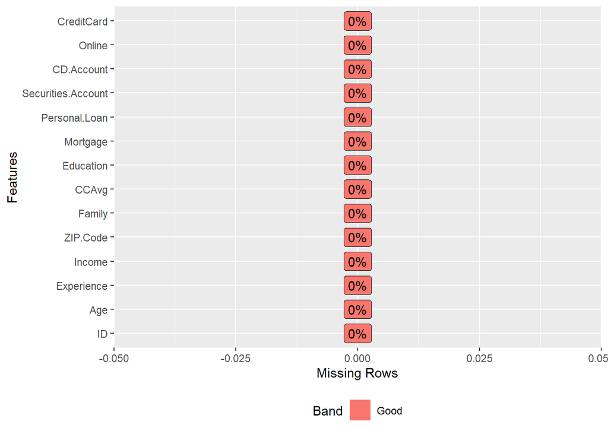

```r
plot_missing(UniBank) # Plots the percentages of missing values
```

```r
# Create a summary statistics table to show metrics, ensuring that missing values are not included
CSUM <- data.frame(mean = sapply(UniBank[,c(2:4, 6:14)], mean,na.rm = T)
                ,median = sapply(UniBank[,c(2:4, 6:14)], median,na.rm = T)
                ,min = sapply(UniBank[,c(2:4, 6:14)], min,na.rm = T)
                ,max = sapply(UniBank[,c(2:4, 6:14)], max,na.rm = T)
                ,sd = sapply(UniBank[,c(2:4, 6:14)], sd,na.rm = T))
colnames(CSUM) = c("Mean","Median","Min","Max","Standard Deviation")
CSUM
```

```
##                         Mean Median Min Max Standard Deviation
## Age                45.338400   45.0  23  67         11.4631656
## Experience         20.104600   20.0  -3  43         11.4679537
## Income             73.774200   64.0   8 224         46.0337293
## Family              2.396400    2.0   1   4          1.1476630
## CCAvg               1.937938    1.5   0  10          1.7476590
## Education           1.881000    2.0   1   3          0.8398691
## Mortgage           56.498800    0.0   0 635        101.7138021
## Personal.Loan       0.096000    0.0   0   1          0.2946207
## Securities.Account  0.104400    0.0   0   1          0.3058093
## CD.Account          0.060400    0.0   0   1          0.2382503
## Online              0.596800    1.0   0   1          0.4905893
## CreditCard          0.294000    0.0   0   1          0.4556375
```

```r
UniBank %>% gather() %>% head() # Reshaping the data which means it collects a set of column names and places them into a single “key” column
```

```
##   key value
## 1  ID     1
## 2  ID     2
## 3  ID     3
## 4  ID     4
## 5  ID     5
## 6  ID     6
```

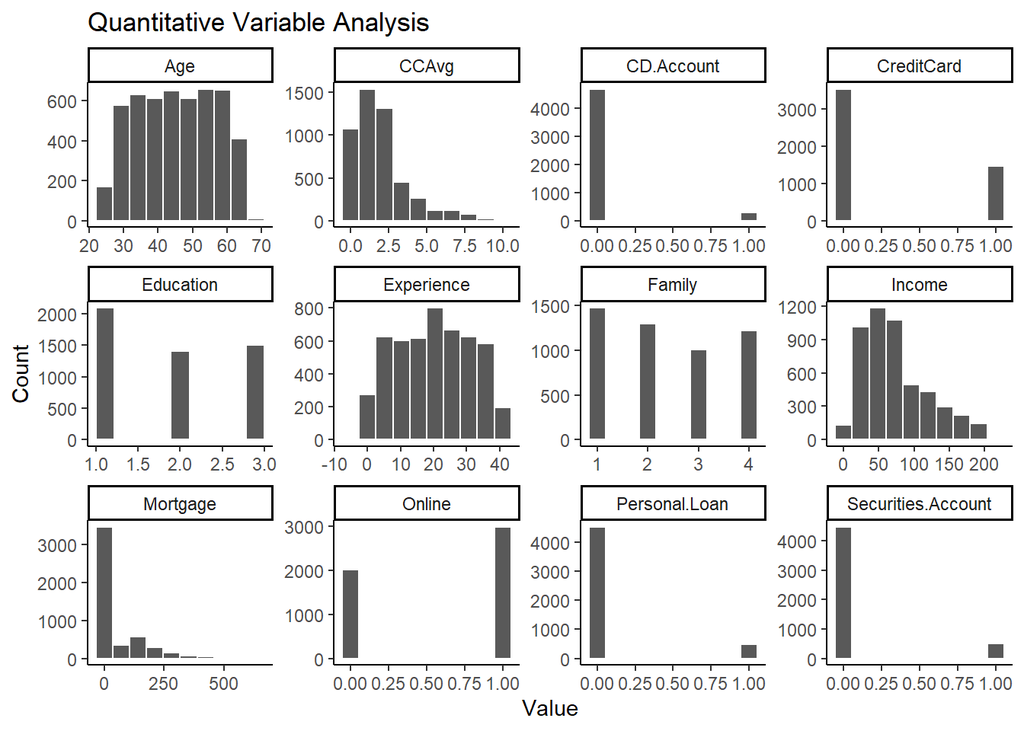

```r
UniBank_data <- UniBank[,-c(1,5)] # Remove ID and Zip from data to review quantitative values

ggplot(gather(data = UniBank_data),aes(value)) +
  geom_histogram(bins = 10, color = "white") + # Creates bin sizing and sets the lines as white
  facet_wrap(~key,scales = "free") + # Converting the graphs into panels
  ggtitle("Quantitative Variable Analysis") + # Title name
  ylab("Count") + xlab("Value") + # Label names
  theme_classic() # A classic theme, with x and y axis lines and no grid lines
```

# 7.2 Exercise - Personal Loan Acceptance

Universal Bank is a relatively young bank growing rapidly in terms of overall customer acquisition. The majority of these customers are liability customers (depositors) with varying sizes of relationship with the bank. The customer base of asset customers (borrowers) is quite small, and the bank is interested in expanding this base rapidly to bring in more loan business. In particular, it wants to explore ways of converting its liability customers to personal loan customers (while retaining them as depositors). A campaign that the bank ran last year for liability customers showed a healthy conversion rate of over 9% success. This has encouraged the retail marketing department to devise smarter campaigns with better target marketing. The goal is to use k-NN to predict whether a new customer will accept a loan offer. This will serve as the basis for the design of a new campaign.  
The file UniversalBank.csv contains data on 5000 customers. The data include customer demographic information (age, income, etc.), the customer’s relationship with the bank (mortgage, securities account, etc.), and the customer response to the last personal loan campaign (Personal Loan). Among these 5000 customers, only 480 (= 9.6%) accepted the personal loan that was offered to them in the earlier campaign. Partition the data into training (60%) and validation (40%) sets.

**A.** *Consider the following customer: Age = 40, Experience = 10, Income = 84, Family = 2, CCAvg = 2, Education_1 = 0, Education_2 = 1, Education_3 = 0, Mortgage = 0, Securities Account = 0, CD Account = 0, Online = 1, and Credit Card = 1. Perform a k-NN classification with all predictors except ID and ZIP code using k = 1. Remember to transform categorical predictors with more than two categories into dummy variables first. Specify the success class as 1 (loan acceptance), and use the default cutoff value of 0.5. How would this customer be classified?*

```r
UniBank$Education = as.factor(UniBank$Education) # treat Education as categorical (R will create dummy variables) (page 245)

UniBank <- UniBank[,-c(1,5)] # Remove ID and Zip from data to review quantitative values (page 245)

dummy <- dummyVars(~.,data = UniBank) # Creates a full set of dummy variables **

bank_dummy <- as.data.frame(predict(dummy, newdata = UniBank)) # **

bank_dummy$Personal.Loan = as.factor(bank_dummy$Personal.Loan) # treat Personal Loan as categorical (R will create dummy variables) (page 245)

str(bank_dummy) # Used for compactly displaying the internal structure of a R object
```

```
## 'data.frame':    5000 obs. of  14 variables:
##  $ Age               : num  25 45 39 35 35 37 53 50 35 34 ...
##  $ Experience        : num  1 19 15 9 8 13 27 24 10 9 ...
##  $ Income            : num  49 34 11 100 45 29 72 22 81 180 ...
##  $ Family            : num  4 3 1 1 4 4 2 1 3 1 ...
##  $ CCAvg             : num  1.6 1.5 1 2.7 1 0.4 1.5 0.3 0.6 8.9 ...
##  $ Education.1       : num  1 1 1 0 0 0 0 0 0 0 ...
##  $ Education.2       : num  0 0 0 1 1 1 1 0 1 0 ...
##  $ Education.3       : num  0 0 0 0 0 0 0 1 0 1 ...
##  $ Mortgage          : num  0 0 0 0 0 155 0 0 104 0 ...
##  $ Personal.Loan     : Factor w/ 2 levels "0","1": 1 1 1 1 1 1 1 1 1 2 ...
##  $ Securities.Account: num  1 1 0 0 0 0 0 0 0 0 ...
##  $ CD.Account        : num  0 0 0 0 0 0 0 0 0 0 ...
##  $ Online            : num  0 0 0 0 0 1 1 0 1 0 ...
##  $ CreditCard        : num  0 0 0 0 1 0 0 1 0 0 ...
```

```r
pl_count <- table(bank_dummy$Personal.Loan) # Create frequency table

prop.table(pl_count) # Calculates the value of each cell in a table as a proportion of all values
```

```
##
##     0     1
## 0.904 0.096
```

After removing ID and Zip Code from the UniBank data frame, I created dummy variables. Additionally, I factored the categorical value (Education) and variable of interest (Personal Loan). At the moment, there are 14 variables since Education is now broken into three levels, and Personal Loan has two levels to represent who has a loan (1) and who does not (0). Throughout this analysis, it is important to note the pre-existing distribution of Personal Loan. Above, you can see that the majority of our population falls under the level that has not accepted the personal loan that was offered to them at 90.4%. Even though 9.6% was given above, this calculation affirms their conclusion and these values can be used at a later point in the analysis.  
**Resource**: https://rdrr.io/cran/caret/man/dummyVars.html

```r
set.seed(1) #  Set the seed for the random number generator for reproducing the partition. (page 258)


# Partitioning into training (60%) and validation (40%) (page 38)
train.index <- sample(rownames(bank_dummy), 0.6*dim(bank_dummy)[1])
train.df <- bank_dummy[train.index, ] # Collect all the columns with training rows into training set (page 38)

valid.index <- setdiff(row.names(bank_dummy), train.index) # # Assign rows that are not already in the training set into validation (page 38)
valid.df <- bank_dummy[valid.index, ] # Collect all the columns with validation rows into validation set (page 38)
```

```r
train.part <- table(train.df$Personal.Loan) / pl_count  # Training set partition breakout
format(train.part) # Treats the elements of a vector as character strings using a common format
```

```
##
##           0           1
## "0.6028761" "0.5729167"
```

```r
valid.part <- table(valid.df$Personal.Loan) / pl_count # Validation set partition breakout
format(valid.part) # Treats the elements of a vector as character strings using a common format
```

```
##
##           0           1
## "0.3971239" "0.4270833"
```

These two tables represent the percentage of customers in the training and validation set, broken out by whether they have a loan (1) or do not (0). As the exercise requested, the data is approximately partitioned at a 60/40 split between sets.

```r
# Initialize normalized training, validation data, complete data frames to originals (page 177)

train.norm.df = train.df
valid.norm.df = valid.df
dummy.norm.df = bank_dummy

# Use preProcess() from the caret package to normalize the quantitative variables (page 177)
norm.values = preProcess(train.df[, c(1:5,9)], method=c("center", "scale")) # Standardize on train for continuous variables
train.norm.df[, c(1:5,9)] = predict(norm.values, newdata = train.df[, c(1:5,9)]) # Means and standard deviation and apply them to train data (predict probabilities) (page 197)
valid.norm.df[, c(1:5,9)] = predict(norm.values, newdata = valid.df[, c(1:5,9)]) # Means and standard deviation and apply them to validation data - means could be slightly different than zero (predict probabilities) (page 197)

# Include customer features to categorize them
new.df = data.frame(Age = 40, Experience = 10, Income = 84, Family = 2, CCAvg = 2, Education_1 = 0, Education_2 = 1, Education_3 = 0, Mortgage = 0, Securities.Account = 0, CD.Account = 0, Online = 1, CreditCard = 1)

# Use knn() to compute K-nearest neighbors (page 177)

new.norm.df = new.df
new.norm.df[, c(1:5,9)] = predict(norm.values, newdata = new.df[, c(1:5,9)]) # means and standard deviation on what we want to test, in this case it would be the given customer (predict probabilities) (page 197)

KNN1 = knn(train = train.norm.df[, -10], test = new.norm.df,
          cl = train.norm.df[, 10], k = 1, prob = T) # (page 177)

KNN1
```

```
## [1] 0
## attr(,"prob")
## [1] 1
## attr(,"nn.index")
##      [,1]
## [1,] 1104
## attr(,"nn.dist")
##           [,1]
## [1,] 0.4999896
## Levels: 0
```

According to the k-nearest-neighbors method, we can use this algorithm to classify a record or customer. Since it was requested that k = 1 is used, a reader must understand that this k may not perform as the best choice in terms of classification. This will classify in a way that is very sensitive to the local characteristics of the training data. In regards to this customer, they would be considered part of the individuals who do not have a personal loan (0). Although I could not find any literature on the “nn.index” output, I would like to assume that since we removed ID, that the 1104 refers to the index of the nearest neighbor or closest observation. The .50 represents the distance to that neighbor from the observation to be classified. In order to see if k = 1 is the best choice, we will next check multiple ks and their frequencies to check if 1 is the best choice.  
**Resource**: pages 176 and 177

**B.** *What is a choice of k that balances between overfitting and ignoring the predictor information?*

```r
# Initialize a data frame with two columns: k, and accuracy (page 178)
k_accuracy <- data.frame(k = seq(1, 20, 1), accuracy = rep(0, 20))

# Compute KNN for different k on validation (page 178)
for(i in 1:20) {
  test1 <- knn(train = train.norm.df[,-10],test = valid.norm.df[,-10], cl = train.norm.df[,10], k = i, prob = T)
  k_accuracy[i, 2] <- confusionMatrix(test1, valid.norm.df[,10])$overall[1]
}
k_accuracy
```

```
##     k accuracy
## 1   1   0.9610
## 2   2   0.9545
## 3   3   0.9620
## 4   4   0.9550
## 5   5   0.9580
## 6   6   0.9495
## 7   7   0.9545
## 8   8   0.9485
## 9   9   0.9540
## 10 10   0.9505
## 11 11   0.9520
## 12 12   0.9470
## 13 13   0.9510
## 14 14   0.9445
## 15 15   0.9470
## 16 16   0.9430
## 17 17   0.9455
## 18 18   0.9415
## 19 19   0.9435
## 20 20   0.9390
```

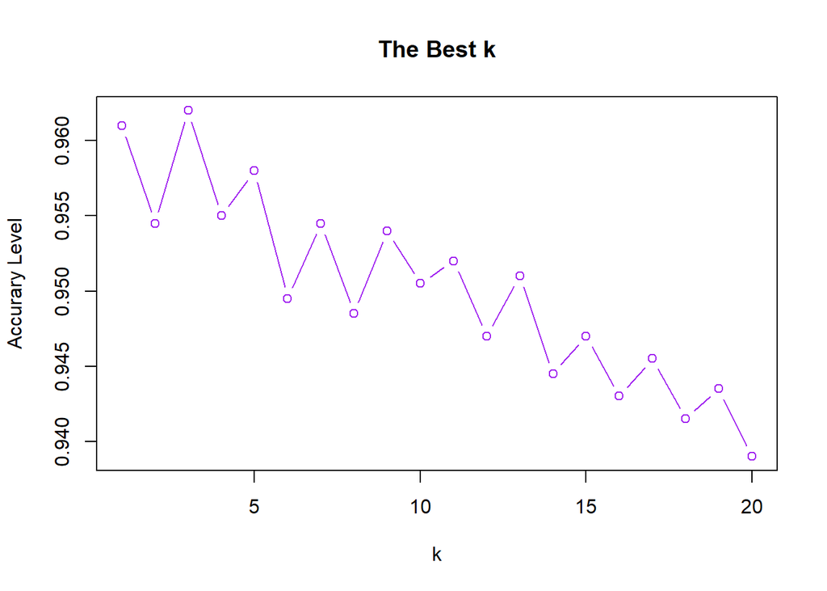

```r
# Initialize a data frame with two columns: k, and accuracy. Used 20 since the k typically falls in range from 1 to 20.
k_accuracy <- data.frame(k = seq(1, 20, 1), accuracy = rep(0, 20))

# Compute knn for different k on validation.
for(i in 1:20) {
  knn.pred = knn(train.norm.df[, -10], valid.norm.df[, -10],
                  cl = train.norm.df[, 10], k = i)

  k_accuracy[i, 2] = confusionMatrix(knn.pred, valid.norm.df[, 10], positive = "1")$overall[1]
}

# Graphical representation of the best k
plot(k_accuracy, type = "b", col = "purple", xlab = "k", ylab = "Accurary Level",
   main = "The Best k")
```

Choosing the right k is critical to ensure that the analyst does not over fit or ignore the predictor information. Typically, the k will fall within a certain range. For instance, ’the advantage of choosing k > 1 is that higher values of k provide smoothing that reduces the risk of overfitting due to noise in the training data. But, if k is too low, we may be fitting to the noise in the data. However, if k is too high, we will miss out on the method’s ability to capture the local structure in the data, one of its main advantages.(pages 177 to 178)

**C.** *Show the confusion matrix for the validation data that results from using the best k*

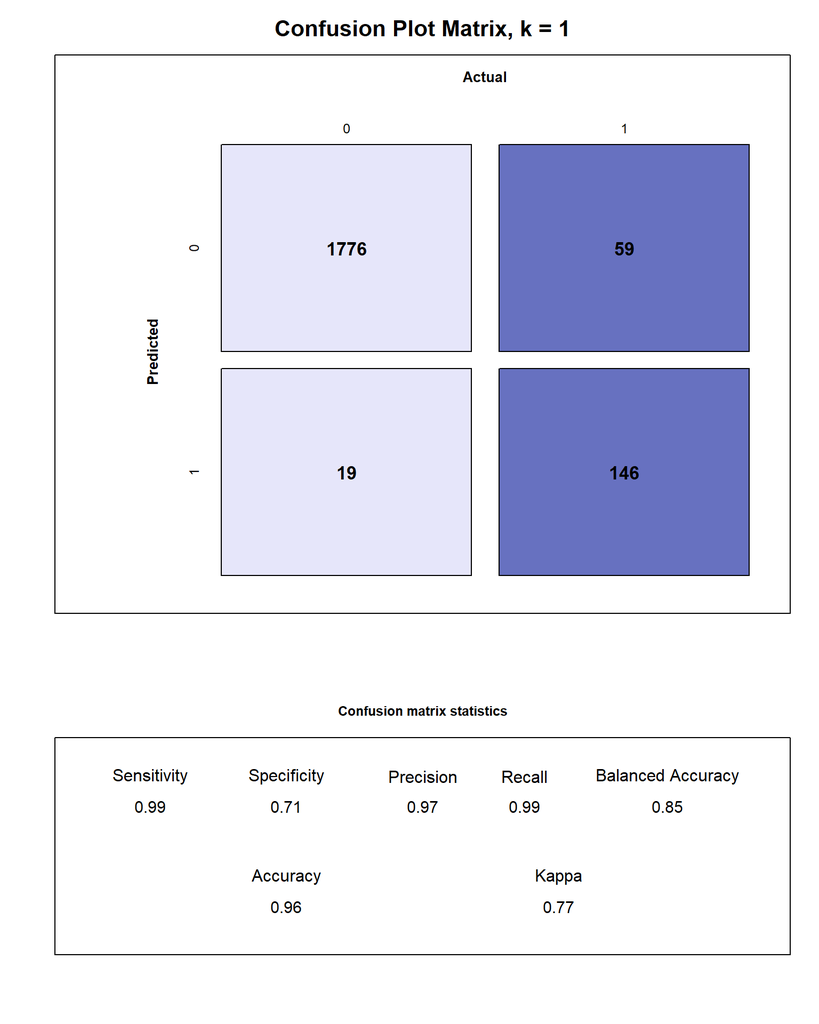

```r
# Above's code with change the dimensions of the confusion matrix
# Use knn() to compute K-nearest neighbors (page 177)
KKN2.pred = knn(train.norm.df[, -10], valid.norm.df[, -10], cl = train.norm.df[, 10], k = 1)

# Creates a confusion matrix plot **
ConfusionTableR::binary_visualiseR(train_labels = KKN2.pred,
                                   truth_labels= valid.norm.df[, 10],
                                   class_label1 = "0",
                                   class_label2 = "1",
                                   quadrant_col1 = "#E6E6FA",
                                   quadrant_col2 = "#6771C0",
                                   custom_title = "Confusion Plot Matrix, k = 1",
                                   text_col= "black")
```

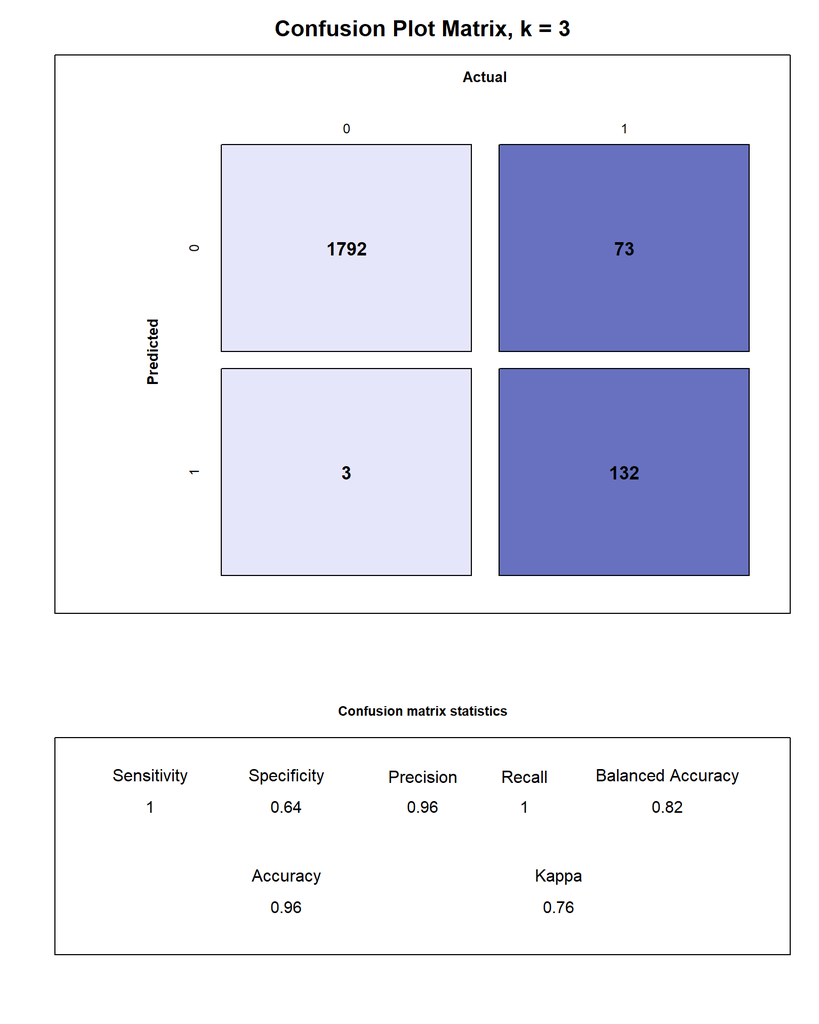

```r
# Above's code with change the dimensions of the confusion matrix
# Use knn() to compute K-nearest neighbors (page 177)
KNN3.pred = knn(train.norm.df[, -10], valid.norm.df[, -10], cl = train.norm.df[, 10], k = 3)

# Creates a confusion matrix plot **
ConfusionTableR::binary_visualiseR(train_labels = KNN3.pred,
                                   truth_labels= valid.norm.df[, 10],
                                   class_label1 = "0",
                                   class_label2 = "1",
                                   quadrant_col1 = "#E6E6FA",
                                   quadrant_col2 = "#6771C0",
                                   custom_title = "Confusion Plot Matrix, k = 3",
                                   text_col= "black")
```

- True Positive (TN) - This is correctly classified as the class if interest / target.
- True Negative (TN) - This is correctly classified as not a class of interest / target.
- False Positive (FP) - This is wrongly classified as the class of interest / target.
- False Negative (FN) - This is wrongly classified as not a class of interest / target.

**Resource**: https://rdrr.io/cran/caret/man/dummyVars.html

**D.** *Consider the following customer: Age = 40, Experience = 10, Income = 84, Family = 2, CCAvg = 2, Education_1 = 0, Education_2 = 1, Education_3 = 0, Mortgage = 0, Securities Account = 0, CD Account = 0, Online = 1 and Credit Card = 1. Classify the customer using the best k.*

```r
# Use knn() to compute K-nearest neighbors (page 177)
new.bank_dummy2= data.frame(Age = 40, Experience = 10, Income = 84, Family = 2, CCAvg = 2, Education_1 = 0, Education_2 = 1, Education_3 = 0, Mortgage = 0, Securities.Account = 0, CD.Account = 0, Online = 1, CreditCard = 1)

KNN2 <- knn(train = train.norm.df[,-10],test = new.norm.df, cl = train.norm.df[,10], k = 3, prob= T)

KNN2
```

```
## [1] 0
## attr(,"prob")
## [1] 1
## attr(,"nn.index")
##      [,1] [,2] [,3]
## [1,] 1104 1187 1281
## attr(,"nn.dist")
##           [,1]      [,2]      [,3]
## [1,] 0.4999896 0.7119304 0.9732413
## Levels: 0
```

If we observe the same customer as above, but use k = 3, we continue to categorize them as a customer who did not accept a loan. The classification does not change since we maximized our accuracy in the validation set. Again, I will assume that 1104, 1187, and 1281 refers to the indices of the three closest neighbors and their corresponding “nn.dist” are their distances from the observation to be classified. This assumption is based off of page 176’s scatterplot, the output on page 177, and Anastasia’s assistance. If for instance we continue to add neighbors, that percentage of accuracy would decrease since k = 4 has an accuracy level less than k = 3.

**E.** *Repartition the data, this time into training, validation, and test sets (50% : 30% : 20%). Apply the k-NN method with the k chosen above. Compare the confusion matrix of the test set with that of the training and validation sets. Comment on the differences and their reason.*

```r
# Partitioning into training (50%), validation (30%), and test (20%) (page 38) - similar procedure in problem A, just added 'test'
train.index <- sample(rownames(bank_dummy), 0.5*dim(bank_dummy)[1])
train.df2 <- bank_dummy[train.index, ]

valid.index <- sample(setdiff(rownames(bank_dummy),train.index), 0.3*dim(bank_dummy)[1])
valid.df2 <- bank_dummy[valid.index, ]

test.index = setdiff(rownames(bank_dummy), union(train.index, valid.index))
test.df2 <- bank_dummy[test.index, ]
```

```r
# Training set partition
train.part2 <- table(train.df2$Personal.Loan) / pl_count  # Training set partition breakout
format(train.part2) # Treats the elements of a vector as character strings using a common format
```

```
##
##           0           1
## "0.5004425" "0.4958333"
```

```r
# Validation set partition
valid.part2 <- table(valid.df2$Personal.Loan) / pl_count # Validation set partition breakout
format(valid.part2) # Treats the elements of a vector as character strings using a common format
```

```
##
##           0           1
## "0.3019912" "0.2812500"
```

```r
# Test set partition
test.part2 <- table(test.df2$Personal.Loan) / pl_count # Test set partition breakout
format(test.part2) # Treats the elements of a vector as character strings using a common format
```

```
##
##           0           1
## "0.1975664" "0.2229167"
```

Prior to reviewing the confusion matrices of the test set against the training and validation sets, the partitioning needs to be observed. Yet again, it is requested to split the data 50/30/20. If we consider these values as whole numbers, training should have 2,500 customers, validation at 1,500, and the remaining 1,000 clients in the test set. Although the our splits are not exactly whole, they are close enough to proceed with the analysis.

```r
# Initialize normalized training, validation data, complete data frames to originals (page 177)
train2 = train.df2
valid2 = valid.df2
test2 = test.df2

# Use preProcess() from the caret package for the quantitative variables
norm.values2 = preProcess(train.df2[, c(1:5,9)], method=c("center", "scale"))
train2[, c(1:5,9)] = predict(norm.values2, train.df2[, c(1:5,9)])
valid2[, c(1:5,9)] = predict(norm.values2, valid.df2[, c(1:5,9)])
test2[, c(1:5,9)] = predict(norm.values2, test.df2[, c(1:5,9)])
```

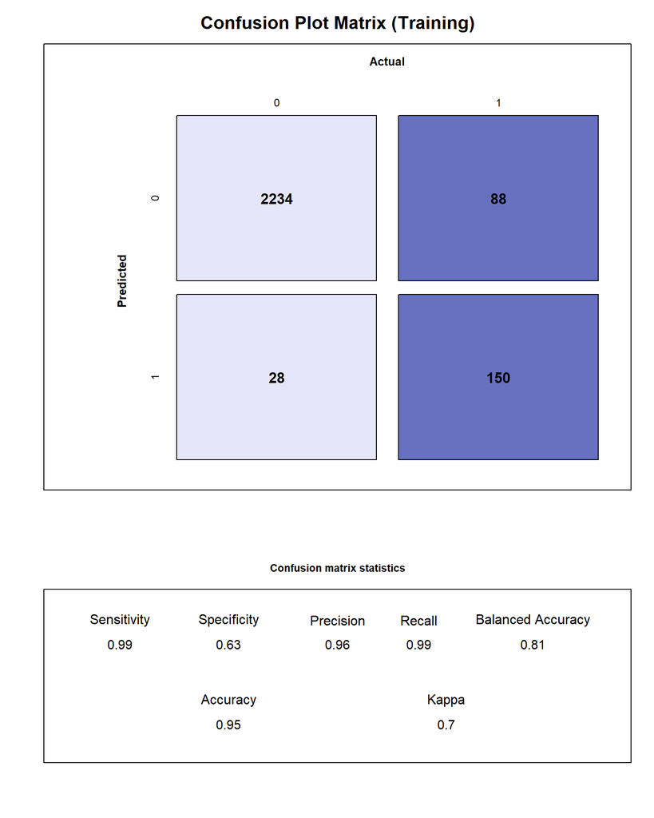

```r
# Above's code with change the dimensions of the confusion matrix
# Use knn() to compute K-nearest neighbors for training data
knn.pred.train = knn(train.df2[, -10], train.df2[, -10], cl = train.df2[, 10], k = 3)

# Creates a confusion matrix plot **
ConfusionTableR::binary_visualiseR(train_labels = knn.pred.train,
                                   truth_labels= train.df2[, 10],
                                   class_label1 = "0",
                                   class_label2 = "1",
                                   quadrant_col1 = "#E6E6FA",
                                   quadrant_col2 = "#6771C0",
                                   custom_title = "Confusion Plot Matrix (Training)",
                                   text_col= "black")
```

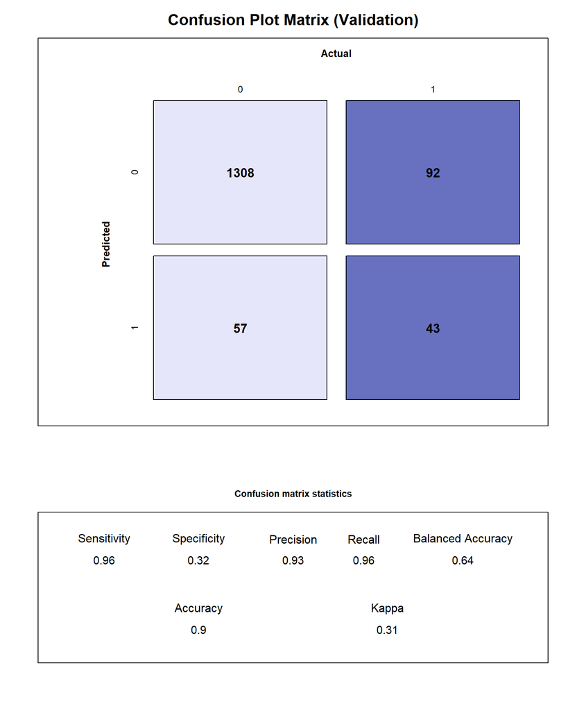

```r
# Above's code with change the dimensions of the confusion matrix
# Use knn() to compute K-nearest neighbors for validation data
knn.pred.val = knn(train.df2[, -10], valid.df2[, -10], train.df2[, 10], k = 3)

# Creates a confusion matrix plot **
ConfusionTableR::binary_visualiseR(train_labels = knn.pred.val,
                                   truth_labels= valid.df2[, 10],
                                   class_label1 = "0",
                                   class_label2 = "1",
                                   quadrant_col1 = "#E6E6FA",
                                   quadrant_col2 = "#6771C0",
                                   custom_title = "Confusion Plot Matrix (Validation)",
                                   text_col= "black")
```

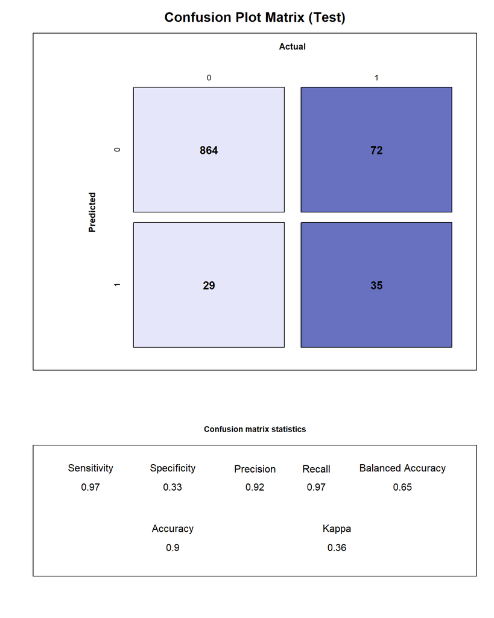

```r
# Above's code with change the dimensions of the confusion matrix
# Use knn() to compute K-nearest neighbors for test data
knn.pred.test = knn(train.df2[, -10], test.df2[, -10], cl = train.df2[, 10], k = 3)

# Creates a confusion matrix plot **
ConfusionTableR::binary_visualiseR(train_labels = knn.pred.test,
                                   truth_labels= test.df2[, 10],
                                   class_label1 = "0",
                                   class_label2 = "1",
                                   quadrant_col1 = "#E6E6FA",
                                   quadrant_col2 = "#6771C0",
                                   custom_title = "Confusion Plot Matrix (Test)",
                                   text_col= "black")
```

Similar to the exercises, we examine the differences not just between the training and validation sets, but we now introduce the test. There are three values that I will focus on: accuracy, sensitivity, and specificity.

| Model | Accuracy | Sensitivity | Specificity |
| --- | --- | --- | --- |
| Training | 95% | 99% | 63% |
| Validation | 90% | 96% | 32% |
| Test | 90% | 97% | 33% |